# FinalProject_week7

31/12/2021

## Instruction

The goal of this exercise is to create a product to highlight the prediction algorithm that you have built and to provide an interface that can be accessed by others. For this project you must submit:

A Shiny app that takes as input a phrase (multiple words) in a text box input and outputs a prediction of the next word.

A slide deck consisting of no more than 5 slides created with R Studio Presenter (https://support.rstudio.com/hc/en-us/articles/200486468-Authoring-R-Presentations) pitching your algorithm and app as if you were presenting to your boss or an investor.

## Data Product

Does the link lead to a Shiny app with a text input box that is running on shinyapps.io?

Does the app load to the point where it can accept input?

When you type a phrase in the input box do you get a prediction of a single word after pressing submit and/or a suitable delay for the model to compute the answer?

Put five phrases drawn from Twitter or news articles in English leaving out the last word. Did it give a prediction for every one?

## Slide Deck

- Does the link lead to a 5 slide deck on R Pubs?
- Does the slide deck contain a description of the algorithm used to make the prediction?
- Does the slide deck describe the app, give instructions, and describe how it functions?
- How would you describe the experience of using this app?
- Does the app present a novel approach and/or is particularly well done?
- Would you hire this person for your own data science startup company?

## A Prediction of A Single Word

#### Shiny App

[Click for A Prediction HERE!](https://tyj7ss-thanida-p.shinyapps.io/FinalProject_week7/?_ga=2.107201026.1245548596.1640940891-1915787804.1639468250)

#### Github

[Click for all sources codes](https://github.com/Momiji5459/final-capstone-porject)

#### UI Screen

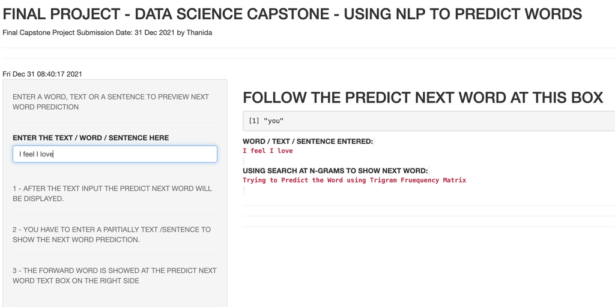